# LSTAT2340 - Analyse de données transcriptomiques: ‘Gene Expression Microarray (Affymetrix)’

Jerome Ambroise - UCL - IREC - CTMA

février 19, 2024,11:17

Dans le document, ci-dessous, nous allons analyser des données d’expression de gènes générées avec une plateforme ‘microarray’ de la marque Affymetrix.

Les données proviennent de l’étude “MicroArray Quality Control (MAQC) project” dont un des papier vous est fourni dans le répertoire ‘doc’. Dans ce document, nous analysons 5 échantillons A (A1, A2, A3, A4 et A5) et 5 échantillons B (B1, B2, B3, B4 et B5) et l’objectif est d’identifier les gènes qui sont modulés.

# 1 Chargement des packages et importation des données.

Nous commençons par charger le package Limma. Limma est un package bioconductor qui dispose d’un “user guide” très complet.

Le package ‘gcrma’ sera utilisé pour le prétraitement des données.

Le package ‘hgu133plus2.db’ sera utilisé pour annoter les sondes (ou “probes”).

Les packages factoextra et FactoMineR seront utilisés pour l’analyse en composantes principales (ACP).

Le package ggplot2 pour les graphiques.

```r
library(limma)
library(gcrma)
library(hgu133plus2.db)
library(factoextra)
library(FactoMineR)
library(ggplot2)
library(gplots)
```

Nous importons les données qui sont situées dans le répertoire 1-data/AFFX Il s’agit de 10 fichiers ‘.CEL’.

```r
rm(list=ls())
files <- list.files('data/AFFX/',full.names = T)
rawfiles <- ReadAffy(filenames=files)
rawfiles
```

```
## AffyBatch object
## size of arrays=1164x1164 features (21 kb)
## cdf=HG-U133_Plus_2 (54675 affyids)
## number of samples=10
## number of genes=54675
## annotation=hgu133plus2
## notes=
```

# 2 Pré-traitement des données.

Les données de microarray sont généralement pré-traitées en 3 étapes:

1: la correction du background

2: la normalisation

3: la transformation (généralement log2)

Avec les données de affymetrix, ces trois étapes sont généralement réalisée avec une seule fonction. GCRMA est une méthode standard pour réaliser ces trois étapes.

```r
expressionset <- gcrma(rawfiles)
```

```
## Adjusting for optical effect..........Done.
## Computing affinities.Done.
## Adjusting for non-specific binding..........Done.
## Normalizing
## Calculating Expression
```

```r
print(expressionset)
```

```
## ExpressionSet (storageMode: lockedEnvironment)
## assayData: 54675 features, 10 samples
##   element names: exprs
## protocolData
##   sampleNames: AFX_1_A1.CEL AFX_1_A2.CEL ... AFX_1_B5.CEL (10 total)
##   varLabels: ScanDate
##   varMetadata: labelDescription
## phenoData
##   sampleNames: AFX_1_A1.CEL AFX_1_A2.CEL ... AFX_1_B5.CEL (10 total)
##   varLabels: sample
##   varMetadata: labelDescription
## featureData: none
## experimentData: use 'experimentData(object)'
## Annotation: hgu133plus2
```

L’expressionset contient de nombreux “slots” dont la matrice d’expression. Il est intéressant de noter que pour le moment le ‘slot’ featureData est vide. Il s’agit du slot dans lequel doit être stocké la signification de chacune des sondes.

## 2.1 assaydata = matrice d’expression

Il est possible d’extraire la matrice d’expression de deux manières.

```r
expression_matrix <- assayData(expressionset)$exprs
expression_matrix <- exprs(expressionset)
dim(expression_matrix)
```

```
## [1] 54675    10
```

```r
expression_matrix[1:10,1:10]
```

```
##           AFX_1_A1.CEL AFX_1_A2.CEL AFX_1_A3.CEL AFX_1_A4.CEL AFX_1_A5.CEL
## 1007_s_at     8.154262     8.258640     8.330232     8.163093     8.108384
## 1053_at       8.718056     8.815388     8.739162     8.799744     8.840262
## 117_at        3.865689     3.937957     3.713142     3.716922     3.775492
## 121_at        4.972485     4.882711     5.054442     5.395737     4.863437
## 1255_g_at     2.245328     2.245328     2.245328     2.245328     2.245328
## 1294_at       5.300109     5.505185     5.243323     5.181908     5.307483
## 1316_at       3.311599     3.323757     3.408077     3.399933     3.322752
## 1320_at       2.305060     2.311773     2.342399     2.305060     2.305060
## 1405_i_at     3.978024     3.814771     3.253105     3.623642     4.058988
## 1431_at       2.959024     2.984661     2.751877     2.928043     2.984483
##           AFX_1_B1.CEL AFX_1_B2.CEL AFX_1_B3.CEL AFX_1_B4.CEL AFX_1_B5.CEL
## 1007_s_at     9.286791     9.339173     9.308381     9.383711     9.287204
## 1053_at       6.098138     6.272793     5.865782     6.015811     6.082908
## 117_at        4.439382     4.292097     4.010092     4.066746     4.148739
## 121_at        4.740067     4.856211     4.799693     4.782419     4.849314
## 1255_g_at     2.263026     2.245328     2.248209     2.245328     2.245328
## 1294_at       3.578577     3.928282     3.928282     4.011878     3.640915
## 1316_at       4.447311     3.746126     4.315038     3.927083     4.065318
## 1320_at       2.306404     2.305060     2.305060     2.305060     2.391690
## 1405_i_at     2.295090     2.295090     2.295090     2.413973     2.385536
## 1431_at       5.347107     5.451553     5.153894     5.379400     5.491991
```

## 2.2 protocolData = données du protocole

```r
pData(protocolData(expressionset))
```

```
##                       ScanDate
## AFX_1_A1.CEL 09/07/05 13:38:28
## AFX_1_A2.CEL 09/07/05 12:01:05
## AFX_1_A3.CEL 09/07/05 12:14:02
## AFX_1_A4.CEL 09/07/05 12:34:41
## AFX_1_A5.CEL 09/07/05 13:50:54
## AFX_1_B1.CEL 09/07/05 13:25:38
## AFX_1_B2.CEL 09/07/05 13:12:47
## AFX_1_B3.CEL 09/07/05 13:00:04
## AFX_1_B4.CEL 09/07/05 12:47:21
## AFX_1_B5.CEL 09/07/05 14:03:23
```

## 2.3 phenoData = données phénotypiques

```r
pData(phenoData(expressionset))
```

```
##              sample
## AFX_1_A1.CEL      1
## AFX_1_A2.CEL      2
## AFX_1_A3.CEL      3
## AFX_1_A4.CEL      4
## AFX_1_A5.CEL      5
## AFX_1_B1.CEL      6
## AFX_1_B2.CEL      7
## AFX_1_B3.CEL      8
## AFX_1_B4.CEL      9
## AFX_1_B5.CEL     10
```

```r
phenoData(expressionset)$group <- c(rep('A',5),rep('B',5))
pData(phenoData(expressionset))
```

```
##              sample group
## AFX_1_A1.CEL      1     A
## AFX_1_A2.CEL      2     A
## AFX_1_A3.CEL      3     A
## AFX_1_A4.CEL      4     A
## AFX_1_A5.CEL      5     A
## AFX_1_B1.CEL      6     B
## AFX_1_B2.CEL      7     B
## AFX_1_B3.CEL      8     B
## AFX_1_B4.CEL      9     B
## AFX_1_B5.CEL     10     B
```

```r
expressionset$group
```

```
##  [1] "A" "A" "A" "A" "A" "B" "B" "B" "B" "B"
```

## 2.4 featureData = information sur chaques probe - gène

```r
featureNames(featureData(expressionset))[1:10]
```

```
##  [1] "1007_s_at" "1053_at"   "117_at"    "121_at"    "1255_g_at" "1294_at"
##  [7] "1316_at"   "1320_at"   "1405_i_at" "1431_at"
```

```r
keytypes(hgu133plus2.db)
```

```
##  [1] "ACCNUM"       "ALIAS"        "ENSEMBL"      "ENSEMBLPROT"  "ENSEMBLTRANS"
##  [6] "ENTREZID"     "ENZYME"       "EVIDENCE"     "EVIDENCEALL"  "GENENAME"
## [11] "GENETYPE"     "GO"           "GOALL"        "IPI"          "MAP"
## [16] "OMIM"         "ONTOLOGY"     "ONTOLOGYALL"  "PATH"         "PFAM"
## [21] "PMID"         "PROBEID"      "PROSITE"      "REFSEQ"       "SYMBOL"
## [26] "UCSCKG"       "UNIPROT"
```

```r
SYMBOL <- mapIds(hgu133plus2.db, keys=as.character(featureNames(featureData(expressionset))),keytype="PROBEID", column="SYMBOL")
ENSEMBL <- mapIds(hgu133plus2.db, keys=as.character(featureNames(featureData(expressionset))),keytype="PROBEID", column="ENSEMBL")
featureData(expressionset)$gene <- SYMBOL
featureData(expressionset)$ensembl <- ENSEMBL
head(pData(featureData(expressionset)))
```

```
##             gene         ensembl
## 1007_s_at   DDR1 ENSG00000204580
## 1053_at     RFC2 ENSG00000049541
## 117_at     HSPA6 ENSG00000173110
## 121_at      PAX8 ENSG00000125618
## 1255_g_at GUCA1A ENSG00000048545
## 1294_at     UBA7 ENSG00000182179
```

```r
dim(pData(featureData(expressionset)))
```

```
## [1] 54675     2
```

## 2.5 Subsetting

Il est possible de sélectionner certains gènes et échantillon dans l’objet expressionset. Tous les slots sont mis à jours. L’outil permet donc d’éviter les erreurs.

```r
expressionset_subset <- expressionset[1:10,1:5]
expressionset_subset
```

```
## ExpressionSet (storageMode: lockedEnvironment)
## assayData: 10 features, 5 samples
##   element names: exprs
## protocolData
##   sampleNames: AFX_1_A1.CEL AFX_1_A2.CEL ... AFX_1_A5.CEL (5 total)
##   varLabels: ScanDate
##   varMetadata: labelDescription
## phenoData
##   sampleNames: AFX_1_A1.CEL AFX_1_A2.CEL ... AFX_1_A5.CEL (5 total)
##   varLabels: sample group
##   varMetadata: labelDescription
## featureData
##   featureNames: 1007_s_at 1053_at ... 1431_at (10 total)
##   fvarLabels: gene ensembl
##   fvarMetadata: labelDescription
## experimentData: use 'experimentData(object)'
## Annotation: hgu133plus2
```

```r
exprs(expressionset_subset)
```

```
##           AFX_1_A1.CEL AFX_1_A2.CEL AFX_1_A3.CEL AFX_1_A4.CEL AFX_1_A5.CEL
## 1007_s_at     8.154262     8.258640     8.330232     8.163093     8.108384
## 1053_at       8.718056     8.815388     8.739162     8.799744     8.840262
## 117_at        3.865689     3.937957     3.713142     3.716922     3.775492
## 121_at        4.972485     4.882711     5.054442     5.395737     4.863437
## 1255_g_at     2.245328     2.245328     2.245328     2.245328     2.245328
## 1294_at       5.300109     5.505185     5.243323     5.181908     5.307483
## 1316_at       3.311599     3.323757     3.408077     3.399933     3.322752
## 1320_at       2.305060     2.311773     2.342399     2.305060     2.305060
## 1405_i_at     3.978024     3.814771     3.253105     3.623642     4.058988
## 1431_at       2.959024     2.984661     2.751877     2.928043     2.984483
```

```r
pData(phenoData(expressionset_subset))
```

```
##              sample group
## AFX_1_A1.CEL      1     A
## AFX_1_A2.CEL      2     A
## AFX_1_A3.CEL      3     A
## AFX_1_A4.CEL      4     A
## AFX_1_A5.CEL      5     A
```

```r
pData(featureData(expressionset_subset))
```

```
##             gene         ensembl
## 1007_s_at   DDR1 ENSG00000204580
## 1053_at     RFC2 ENSG00000049541
## 117_at     HSPA6 ENSG00000173110
## 121_at      PAX8 ENSG00000125618
## 1255_g_at GUCA1A ENSG00000048545
## 1294_at     UBA7 ENSG00000182179
## 1316_at     THRA ENSG00000126351
## 1320_at   PTPN21 ENSG00000070778
## 1405_i_at   CCL5 ENSG00000271503
## 1431_at   CYP2E1 ENSG00000130649
```

# 3 Analyse en Composantes Principales

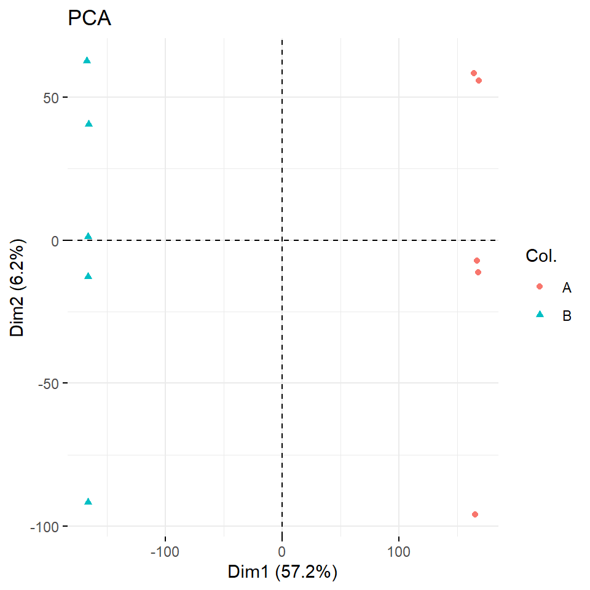

```r
pca_conc <- PCA(t(exprs(expressionset)),  graph = F)
fviz_pca_ind(pca_conc, col.ind = expressionset$group,repel = T ,title='PCA',geom.ind='point',invisible='quali')
```

# 4 Création des modèles statistiques pour détecter les gènes modulés

Pour rappel, le but est de comparer les niveaux d’expression de chacun des gènes entre les 5 échantillons ‘A’ et les 5 échantillons ‘B’. Nous commençons par spécifier à R le design de notre expérience

```r
group <- expressionset$group
mydesign <- model.matrix(~group )
print(mydesign)
```

```
##    (Intercept) groupB
## 1            1      0
## 2            1      0
## 3            1      0
## 4            1      0
## 5            1      0
## 6            1      1
## 7            1      1
## 8            1      1
## 9            1      1
## 10           1      1
## attr(,"assign")
## [1] 0 1
## attr(,"contrasts")
## attr(,"contrasts")$group
## [1] "contr.treatment"
```

Une fois que le modèle est spécifié, il est possible de créer les modèles pour chacun des gènes et de calculer les statistiques de test et les p-valeurs associées à chacun des gestes. Cela se fait en deux étapes avec les fonctions ‘lmFit’ et ‘eBayes’ du package ‘limma’.

```r
fit <- lmFit(expressionset, design=mydesign)
efit <- eBayes(fit)
```

Une fois les modèles construits, on peut extraire les logFC, les p-valeurs brutes, les p-valeurs ajustées (avec la méthode spécifiée, ici Benjamini-Hochberg pour contrôler le FDR)

```r
topTable(efit, coef=2,adjust.method='BH',number = 15)
```

```
##                 gene         ensembl      logFC  AveExpr         t      P.Value
## 209773_s_at     RRM2 ENSG00000171848  -9.196435 6.857228 -540.9261 1.556850e-20
## 206647_at        HBZ ENSG00000130656  -9.786900 8.233455 -514.9646 2.362099e-20
## 219466_s_at    APOA2 ENSG00000158874 -10.582682 7.709977 -443.9462 8.308908e-20
## 240433_x_at    CADM2 ENSG00000175161   7.180321 5.838633  419.6347 1.339227e-19
## 209138_x_at    IGLC1 ENSG00000211675  -9.045762 9.666858 -410.3391 1.619237e-19
## 229039_at       SYN2 ENSG00000157152   8.781716 7.237703  408.9347 1.666979e-19
## 211298_s_at      ALB ENSG00000163631 -11.404550 7.990782 -397.4741 2.121119e-19
## 211276_at     TCEAL2 ENSG00000184905   9.037204 6.761832  373.9676 3.555979e-19
## 206427_s_at    MLANA ENSG00000120215  -8.718217 6.711987 -347.5272 6.620152e-19
## 205751_at     SH3GL2 ENSG00000107295   9.146408 6.887368  337.2631 8.535336e-19
## 227828_s_at    EVA1A ENSG00000115363  -3.689660 4.099643 -331.6773 9.833206e-19
## 1556057_s_at NEUROD1 ENSG00000162992   8.973249 6.735424  330.0534 1.025086e-18
## 231771_at       GJB6 ENSG00000121742   6.481678 5.484070  329.3500 1.043791e-18
## 1552721_a_at    FGF1 ENSG00000113578   6.932090 5.709488  298.3768 2.410742e-18
## 219918_s_at     ASPM ENSG00000066279  -7.833844 6.198963 -297.7897 2.451323e-18
##                 adj.P.Val        B
## 209773_s_at  6.457387e-16 34.89129
## 206647_at    6.457387e-16 34.72841
## 219466_s_at  1.514298e-15 34.17187
## 240433_x_at  1.519035e-15 33.93415
## 209138_x_at  1.519035e-15 33.83546
## 229039_at    1.519035e-15 33.82014
## 211298_s_at  1.656746e-15 33.69103
## 211276_at    2.430290e-15 33.40125
## 206427_s_at  4.021742e-15 33.02942
## 205751_at    4.389942e-15 32.87013
## 227828_s_at  4.389942e-15 32.77957
## 1556057_s_at 4.389942e-15 32.75272
## 231771_at    4.389942e-15 32.74101
## 1552721_a_at 8.532158e-15 32.17623
## 219918_s_at  8.532158e-15 32.16452
```

# 5 Quelques graphiques

## 5.1 Heatmap

Nous allons représenter une heatmap des 30 premiers gènes (choix arbitraire des gènes).

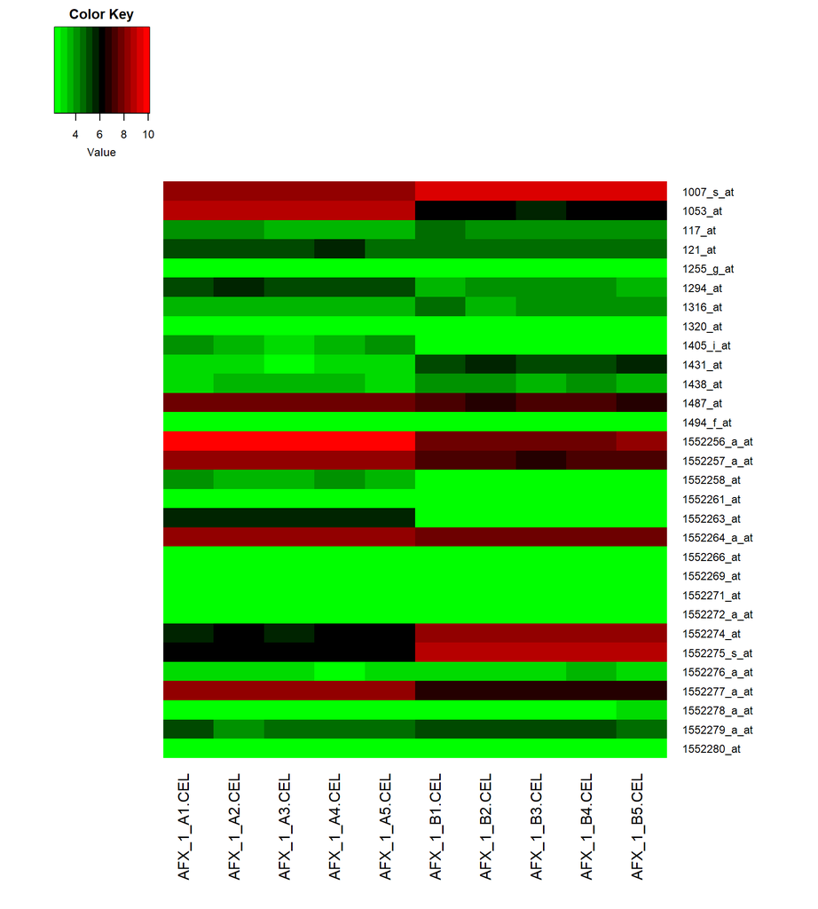

```r
heatmap.2(exprs(expressionset[1:30,1:10]),col='greenred',trace='none',dendrogram='none',margins = c(10,10),symbreaks=F,symkey = FALSE,Rowv=F,Colv = F,keysize=1,density.info='none')
```

## 5.2 Volcano plot

Nous allons représenter un volcano-plot.

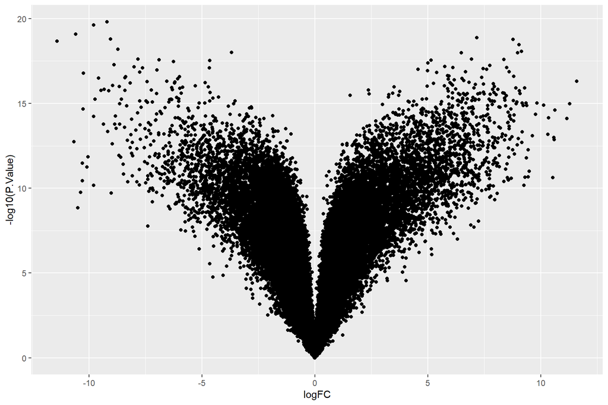

```r
complete_table <- topTable(efit, coef=2,adjust.method='BH',number = dim(expressionset)[1])
ggplot(data = complete_table,aes(x =logFC ,y = -log10(P.Value)))+
  geom_point()
```